# Course 5 Week 2 Assignment

Halonen, Ally

10/19/2020

## Part 1

First, clean the dataset and calculate the total number of steps taken per day.

```r
df <- read.csv('activity.csv')
df$date <- as.Date(df$date, format = "%Y-%m-%d")
df <- df %>%
  rename(date_col = date)
df_with_na <- df
df <- na.omit(df)

df_days <- df %>%
  group_by(date_col) %>%
  summarise(steps = sum(steps))

head(df_days)
```

```
## # A tibble: 6 x 2
##   date_col   steps
##   <date>     <int>
## 1 2012-10-02   126
## 2 2012-10-03 11352
## 3 2012-10-04 12116
## 4 2012-10-05 13294
## 5 2012-10-06 15420
## 6 2012-10-07 11015
```

Then, make a histogram of the total number of steps taken each day

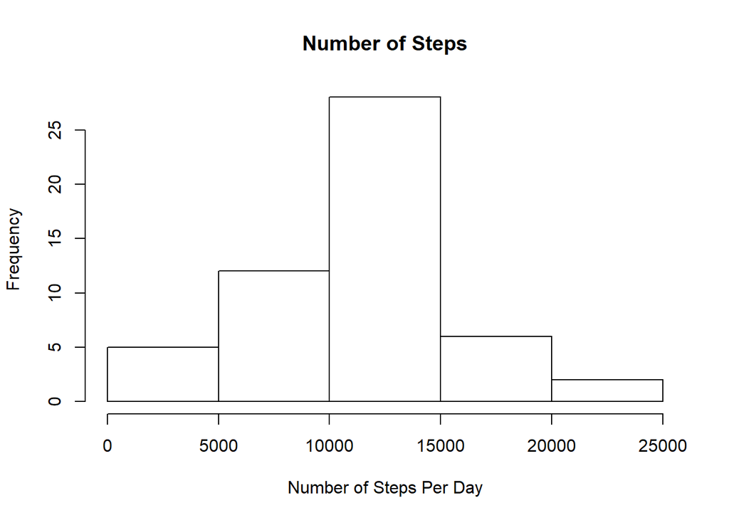

```r
hist(df_days$steps, xlab = 'Number of Steps Per Day', main = "Number of Steps")
```

Calculate the mean and median.

```r
mean_steps <- mean(df_days$steps)
median_steps <- median(df_days$steps)
mean_steps
```

```
## [1] 10766.19
```

```r
median_steps
```

```
## [1] 10765
```

## Part 2

Make a time series plot (i.e. type = “l”) of the 5-minute interval (x-axis) and the average number of steps taken, averaged across all days (y-axis).

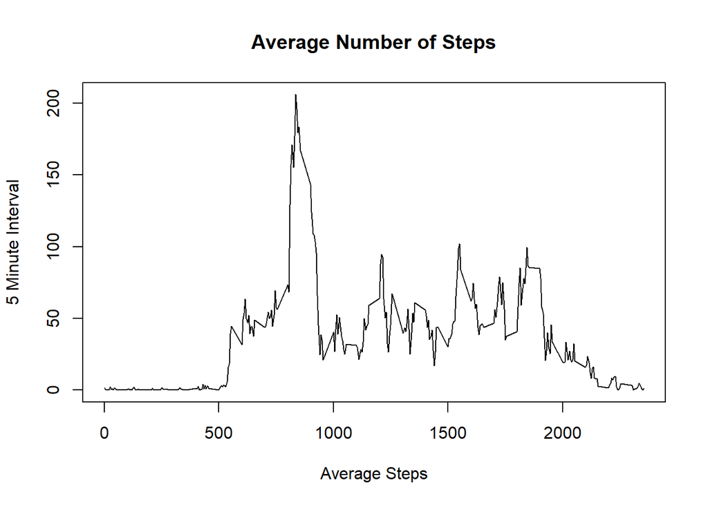

```r
df_avg <- df %>%
  group_by(interval) %>%
  summarise(steps = mean(steps))

plot(df_avg$interval, df_avg$steps, type = "l", ylab = "5 Minute Interval", xlab = "Average Steps", main = "Average Number of Steps")
```

Which 5-minute interval, on average across all the days in the dataset, contains the maximum number of steps?

```r
df_avg$interval[df_avg$steps == max(df_avg$steps)]
```

```
## [1] 835
```